# Ford GoBike System Data exploration

## by Moaz Magdy

## Investigation Overview

> The goal of this presentation is to investigate the features are best for predicting the trip duration. The features of interest were: trip duration, member gender, user type, trip start time, and member age

## Dataset Overview

> This dataset includes trip information from Ford GoBike, a bike-sharing system in California's San Francisco Bay Area established in 2013. The data includes trips from Ford GoBike system for Feb. 2019.

## Distribution of the main variable of interest: trip duration.

The distribution is highly right_skewed with several extreme values. So, we will consider trip durations greater than the maximum whisker (Q3 + 1.5 IQR) as outliers and we will drop them out, then we will apply a log transformation on the data.

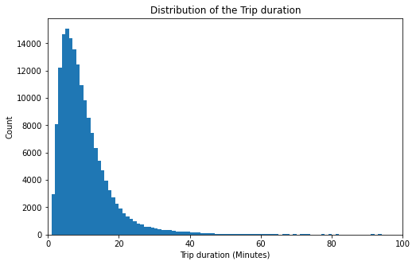

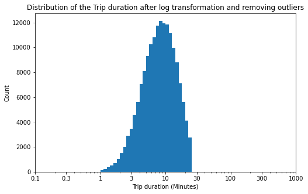

When plotted on a log-scale, the trip duration distribution looks unimodal, with one large peak around 10 minutes

## Distribution of user type feature.

The proportion plot for the user_type feature shows that about %90 of users are subscribers.

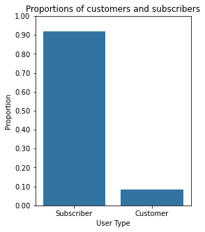

## Distribution of member gender feature.

The proportions plot for member gender feature shows that about 74% of members are males, and 24% are females.

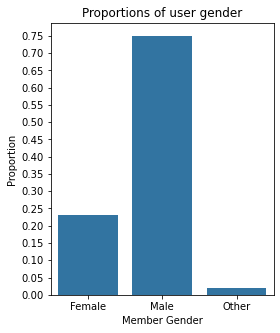

## Distribution of trip start time.

The above histogram for number of trips over the day shows that the distribution is bimodal, with one big peak around 8 am (1 hour after sunrise), and one big peak around 5 pm (1 hour before sunset).

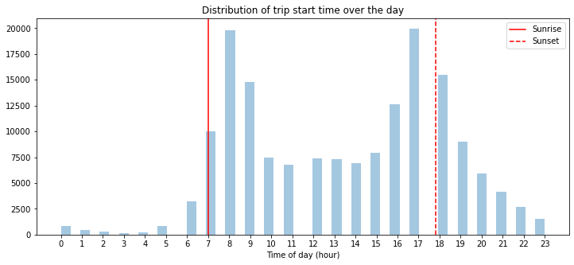

## Distribution of member age

The distribution of member age is right_skewed, with most users below 40 years, few users between 40 and 60, and very few users above 60.

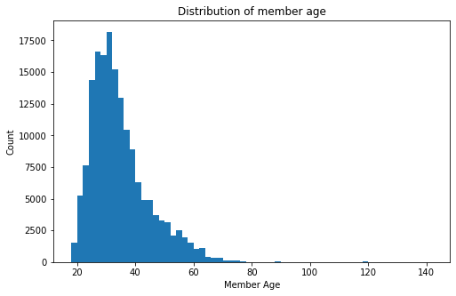

## Effect of member gender on trip duration

The member gender seems to a little effect on trip durations such that females tend ride slightly longer than males.

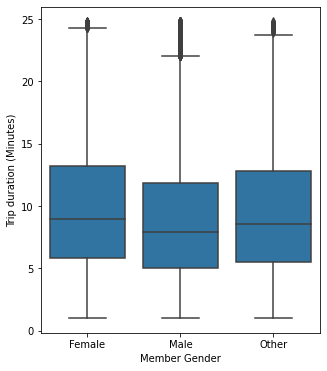

## Effect of user type on trip duration

User type seems to have a strong effect on trip duration. The trip duration for customers is longer than that for subscribers regardless of day of week.

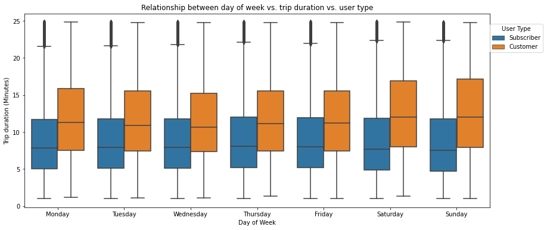

## Effect of member age on trip duration

Surprisingly, the member age doesn't seem to have an effect on the trip duration.

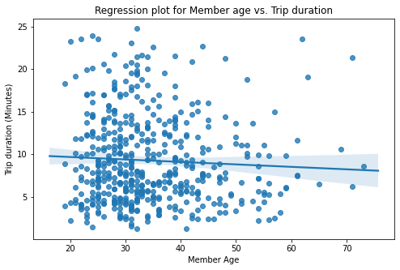